# 951c8476-14b3-4121-9d5c-68b4e8470103

```python
import pandas as pd
```

### Откройте файл с данными и изучите общую информацию

**Задание 1.** Откройте файл `/datasets/calls.csv`, сохраните датафрейм в переменную `calls`.

```python
calls = pd.read_csv('/datasets/calls.csv')
```

**Задание 2.** Выведите первые 5 строк датафрейма `calls`.

```python
calls.head(5)
```

|  | id | call_date | duration | user_id |
| --- | --- | --- | --- | --- |
| 0 | 1000_0 | 2018-07-25 | 0.00 | 1000 |
| 1 | 1000_1 | 2018-08-17 | 0.00 | 1000 |
| 2 | 1000_2 | 2018-06-11 | 2.85 | 1000 |
| 3 | 1000_3 | 2018-09-21 | 13.80 | 1000 |
| 4 | 1000_4 | 2018-12-15 | 5.18 | 1000 |

**Задание 3.** Выведите основную информацию для датафрейма `calls` с помощью метода `info()`.

```python
calls.info()
```

```
<class 'pandas.core.frame.DataFrame'>
RangeIndex: 202607 entries, 0 to 202606
Data columns (total 4 columns):
 #   Column     Non-Null Count   Dtype
---  ------     --------------   -----
 0   id         202607 non-null  object
 1   call_date  202607 non-null  object
 2   duration   202607 non-null  float64
 3   user_id    202607 non-null  int64
dtypes: float64(1), int64(1), object(2)
memory usage: 6.2+ MB
```

**Задание 4.** С помощью метода `hist()` выведите гистограмму для столбца с продолжительностью звонков. Подумайте о том, как распределены данные.

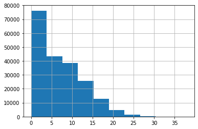

```python
calls['duration'].hist()
```

Очевидно, что преобладают звонки продолжительностью до 5 минут

**Задание 5.** Откройте файл `/datasets/internet.csv`, сохраните датафрейм в переменную `sessions`.

```python
sessions = pd.read_csv('/datasets/internet.csv')
```

**Задание 6.** Выведите первые 5 строк датафрейма `sessions`.

```python
sessions.head(5)
```

|  | Unnamed: 0 | id | mb_used | session_date | user_id |
| --- | --- | --- | --- | --- | --- |
| 0 | 0 | 1000_0 | 112.95 | 2018-11-25 | 1000 |
| 1 | 1 | 1000_1 | 1052.81 | 2018-09-07 | 1000 |
| 2 | 2 | 1000_2 | 1197.26 | 2018-06-25 | 1000 |
| 3 | 3 | 1000_3 | 550.27 | 2018-08-22 | 1000 |
| 4 | 4 | 1000_4 | 302.56 | 2018-09-24 | 1000 |

**Задание 7.** Выведите основную информацию для датафрейма sessions с помощью метода `info()`.

```python
sessions.info()
```

```
<class 'pandas.core.frame.DataFrame'>
RangeIndex: 149396 entries, 0 to 149395
Data columns (total 5 columns):
 #   Column        Non-Null Count   Dtype
---  ------        --------------   -----
 0   Unnamed: 0    149396 non-null  int64
 1   id            149396 non-null  object
 2   mb_used       149396 non-null  float64
 3   session_date  149396 non-null  object
 4   user_id       149396 non-null  int64
dtypes: float64(1), int64(2), object(2)
memory usage: 5.7+ MB
```

**Задание 8.** С помощью метода `hist()` выведите гистограмму для столбца с количеством потраченных мегабайт.

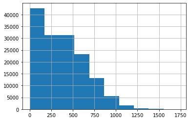

```python
sessions['mb_used'].hist()
```

**Задание 9.** Откройте файл `/datasets/messages.csv`, сохраните датафрейм в переменную `messages`.

```python
messages = pd.read_csv('/datasets/messages.csv')
```

**Задание 10.** Выведите первые 5 строк датафрейма `messages`.

```python
messages.head(5)
```

|  | id | message_date | user_id |
| --- | --- | --- | --- |
| 0 | 1000_0 | 2018-06-27 | 1000 |
| 1 | 1000_1 | 2018-10-08 | 1000 |
| 2 | 1000_2 | 2018-08-04 | 1000 |
| 3 | 1000_3 | 2018-06-16 | 1000 |
| 4 | 1000_4 | 2018-12-05 | 1000 |

**Задание 11.** Выведите основную информацию для датафрейма `messages` с помощью метода `info()`.

```python
messages.info()
```

```
<class 'pandas.core.frame.DataFrame'>
RangeIndex: 123036 entries, 0 to 123035
Data columns (total 3 columns):
 #   Column        Non-Null Count   Dtype
---  ------        --------------   -----
 0   id            123036 non-null  object
 1   message_date  123036 non-null  object
 2   user_id       123036 non-null  int64
dtypes: int64(1), object(2)
memory usage: 2.8+ MB
```

**Задание 12.** Откройте файл `/datasets/tariffs.csv`, сохраните датафрейм в переменную `tariffs`.

```python
tariffs = pd.read_csv('/datasets/tariffs.csv')
```

**Задание 13.** Выведите весь датафрейм `tariffs`.

```python
tariffs
```

|  | messages_included | mb_per_month_included | minutes_included | rub_monthly_fee | rub_per_gb | rub_per_message | rub_per_minute | tariff_name |
| --- | --- | --- | --- | --- | --- | --- | --- | --- |
| 0 | 50 | 15360 | 500 | 550 | 200 | 3 | 3 | smart |
| 1 | 1000 | 30720 | 3000 | 1950 | 150 | 1 | 1 | ultra |

**Задание 14.** Выведите основную информацию для датафрейма `tariffs` с помощью метода `info()`.

```python
tariffs.info()
```

```
<class 'pandas.core.frame.DataFrame'>
RangeIndex: 2 entries, 0 to 1
Data columns (total 8 columns):
 #   Column                 Non-Null Count  Dtype
---  ------                 --------------  -----
 0   messages_included      2 non-null      int64
 1   mb_per_month_included  2 non-null      int64
 2   minutes_included       2 non-null      int64
 3   rub_monthly_fee        2 non-null      int64
 4   rub_per_gb             2 non-null      int64
 5   rub_per_message        2 non-null      int64
 6   rub_per_minute         2 non-null      int64
 7   tariff_name            2 non-null      object
dtypes: int64(7), object(1)
memory usage: 256.0+ bytes
```

**Задание 15.** Откройте файл `/datasets/users.csv`, сохраните датафрейм в переменную `users`.

```python
users = pd.read_csv('/datasets/users.csv')
```

**Задание 16.** Выведите первые 5 строк датафрейма `users`.

```python
users.head(5)
```

|  | user_id | age | churn_date | city | first_name | last_name | reg_date | tariff |
| --- | --- | --- | --- | --- | --- | --- | --- | --- |
| 0 | 1000 | 52 | NaN | Краснодар | Рафаил | Верещагин | 2018-05-25 | ultra |
| 1 | 1001 | 41 | NaN | Москва | Иван | Ежов | 2018-11-01 | smart |
| 2 | 1002 | 59 | NaN | Стерлитамак | Евгений | Абрамович | 2018-06-17 | smart |
| 3 | 1003 | 23 | NaN | Москва | Белла | Белякова | 2018-08-17 | ultra |
| 4 | 1004 | 68 | NaN | Новокузнецк | Татьяна | Авдеенко | 2018-05-14 | ultra |

**Задание 17.** Выведите основную информацию для датафрейма `users` с помощью метода `info()`.

```python
users.info()
```

```
<class 'pandas.core.frame.DataFrame'>
RangeIndex: 500 entries, 0 to 499
Data columns (total 8 columns):
 #   Column      Non-Null Count  Dtype
---  ------      --------------  -----
 0   user_id     500 non-null    int64
 1   age         500 non-null    int64
 2   churn_date  38 non-null     object
 3   city        500 non-null    object
 4   first_name  500 non-null    object
 5   last_name   500 non-null    object
 6   reg_date    500 non-null    object
 7   tariff      500 non-null    object
dtypes: int64(2), object(6)
memory usage: 31.4+ KB
```

### Подготовьте данные

**Задание 18.** Приведите столбцы

- `reg_date` из таблицы `users`
- `churn_date` из таблицы `users`
- `call_date` из таблицы `calls`
- `message_date` из таблицы `messages`
- `session_date` из таблицы `sessions`

к новому типу с помощью метода `to_datetime()`.

```python
users['reg_date'] = pd.to_datetime(users['reg_date'])
#обработка столбца reg_date
users['churn_date'] = pd.to_datetime(users['churn_date'])
#обработка столбца churn_date
calls['call_date'] = pd.to_datetime(calls['call_date'])
# обработка столбца call_date
messages['message_date'] = pd.to_datetime(messages['message_date'])
# обработка столбца message_date
sessions['session_date'] = pd.to_datetime(sessions['session_date'])
# обработка столбца session_date
```

```python
sessions.info()
```

```
<class 'pandas.core.frame.DataFrame'>
RangeIndex: 149396 entries, 0 to 149395
Data columns (total 5 columns):
 #   Column        Non-Null Count   Dtype
---  ------        --------------   -----
 0   Unnamed: 0    149396 non-null  int64
 1   id            149396 non-null  object
 2   mb_used       149396 non-null  float64
 3   session_date  149396 non-null  datetime64[ns]
 4   user_id       149396 non-null  int64
dtypes: datetime64[ns](1), float64(1), int64(2), object(1)
memory usage: 5.7+ MB
```

**Задание 19.** В данных вы найдёте звонки с нулевой продолжительностью. Это не ошибка: нулями обозначены пропущенные звонки, поэтому их не нужно удалять.

Однако в столбце `duration` датафрейма `calls` значения дробные. Округлите значения столбца `duration` вверх с помощью метода `numpy.ceil()` и приведите столбец `duration` к типу `int`.

```python
import numpy as np

calls['duration'] = np.ceil(calls['duration']).astype(int)

# округление значений столбца duration с помощью np.ceil() и приведение типа к int
```

**Задание 20.** Удалите столбец `Unnamed: 0` из датафрейма `sessions`. Столбец с таким названием возникает, когда данные сохраняют с указанием индекса (`df.to_csv(..., index=column)`). Он сейчас не понадобится.

```python
sessions = sessions.drop(columns = ['Unnamed: 0'])
```

**Задание 21.** Создайте столбец `month` в датафрейме `calls` с номером месяца из столбца `call_date`.

```python
calls.head(5)
```

|  | id | call_date | duration | user_id |
| --- | --- | --- | --- | --- |
| 0 | 1000_0 | 2018-07-25 | 0 | 1000 |
| 1 | 1000_1 | 2018-08-17 | 0 | 1000 |
| 2 | 1000_2 | 2018-06-11 | 3 | 1000 |
| 3 | 1000_3 | 2018-09-21 | 14 | 1000 |
| 4 | 1000_4 | 2018-12-15 | 6 | 1000 |

```python
calls['month'] = calls['call_date'].apply(lambda x: x.month)
```

```python
#Проверим, что получилось:

calls.head(5)
```

|  | id | call_date | duration | user_id | month |
| --- | --- | --- | --- | --- | --- |
| 0 | 1000_0 | 2018-07-25 | 0 | 1000 | 7 |
| 1 | 1000_1 | 2018-08-17 | 0 | 1000 | 8 |
| 2 | 1000_2 | 2018-06-11 | 3 | 1000 | 6 |
| 3 | 1000_3 | 2018-09-21 | 14 | 1000 | 9 |
| 4 | 1000_4 | 2018-12-15 | 6 | 1000 | 12 |

**Задание 22.** Создайте столбец `month` в датафрейме `messages` с номером месяца из столбца `message_date`.

```python
messages['month'] = messages['message_date'].apply(lambda x: x.month)
```

**Задание 23.** Создайте столбец `month` в датафрейме `sessions` с номером месяца из столбца `session_date`.

```python
sessions['month'] = sessions['session_date'].apply(lambda x: x.month)
```

**Задание 24.** Посчитайте количество сделанных звонков разговора для каждого пользователя по месяцам.

```python
# подсчёт количества звонков для каждого пользователя по месяцам

calls_per_month = calls.groupby(['user_id','month']).agg(calls=('duration', 'count'))
```

```python
# вывод 30 первых строк на экран

calls_per_month.head(30)
```

| user_id | month | calls |
| --- | --- | --- |
| 1000 | 5 | 22 |
|  | 6 | 43 |
|  | 7 | 47 |
|  | 8 | 52 |
|  | 9 | 58 |
|  | 10 | 57 |
|  | 11 | 43 |
|  | 12 | 46 |
| 1001 | 11 | 59 |
|  | 12 | 63 |
| 1002 | 6 | 15 |
|  | 7 | 26 |
|  | 8 | 42 |
|  | 9 | 36 |
|  | 10 | 33 |
|  | 11 | 32 |
|  | 12 | 33 |
| 1003 | 8 | 55 |
|  | 9 | 134 |
|  | 10 | 108 |
|  | 11 | 115 |
|  | 12 | 108 |
| 1004 | 5 | 9 |
|  | 6 | 31 |
|  | 7 | 22 |
|  | 8 | 19 |
|  | 9 | 26 |
|  | 10 | 29 |
|  | 11 | 19 |
|  | 12 | 21 |

**Задание 25.** Посчитайте количество израсходованных минут разговора для каждого пользователя по месяцам и сохраните в переменную `minutes_per_month`. Вам понадобится

- сгруппировать датафрейм с информацией о звонках по двум столбцам — с идентификаторами пользователей и номерами месяцев;
- после группировки выбрать столбец `duration`
- затем применить метод для подсчёта суммы.

Выведите первые 30 строчек `minutes_per_month`.

```python
# подсчёт израсходованных минут для каждого пользователя по месяцам

minutes_per_month = calls.groupby(['user_id','month']).agg(minutes = ('duration','sum'))
```

```python
# вывод первых 30 строк на экран
minutes_per_month
```

| user_id | month | minutes |
| --- | --- | --- |
| 1000 | 5 | 159 |
|  | 6 | 172 |
|  | 7 | 340 |
|  | 8 | 408 |
|  | 9 | 466 |
| ... | ... | ... |
| 1498 | 10 | 247 |
| 1499 | 9 | 70 |
|  | 10 | 449 |
|  | 11 | 612 |
|  | 12 | 492 |

3174 rows × 1 columns

**Задание 26.** Посчитайте количество отправленных сообщений по месяцам для каждого пользователя и сохраните в переменную `messages_per_month`. Вам понадобится

- сгруппировать датафрейм с информацией о сообщениях по двум столбцам — с идентификаторами пользователей и номерами месяцев;
- после группировки выбрать столбец `message_date`;
- затем применить метод для подсчёта количества.

Выведите первые 30 строчек `messages_per_month`.

```python
# подсчёт количества отправленных сообщений для каждого пользователя по месяцам #{"id":lambda x: len(np.unique(x)) }

messages_per_month = messages.groupby(['user_id','month']).agg(messages=('message_date', 'count'))
```

```python
# вывод первых 30 строк на экран
messages_per_month=messages_per_month.rename(columns = {'id': 'messages_count'})
messages_per_month.head(30)
```

| user_id | month | messages |
| --- | --- | --- |
| 1000 | 5 | 22 |
|  | 6 | 60 |
|  | 7 | 75 |
|  | 8 | 81 |
|  | 9 | 57 |
|  | 10 | 73 |
|  | 11 | 58 |
|  | 12 | 70 |
| 1002 | 6 | 4 |
|  | 7 | 11 |
|  | 8 | 13 |
|  | 9 | 4 |
|  | 10 | 10 |
|  | 11 | 16 |
|  | 12 | 12 |
| 1003 | 8 | 37 |
|  | 9 | 91 |
|  | 10 | 83 |
|  | 11 | 94 |
|  | 12 | 75 |
| 1004 | 5 | 95 |
|  | 6 | 134 |
|  | 7 | 181 |
|  | 8 | 151 |
|  | 9 | 146 |
|  | 10 | 165 |
|  | 11 | 158 |
|  | 12 | 162 |
| 1005 | 1 | 7 |
|  | 2 | 38 |

**Задание 27.** Посчитайте количество потраченных мегабайт по месяцам для каждого пользователя и сохраните в переменную `sessions_per_month`. Вам понадобится

- сгруппировать датафрейм с информацией о сообщениях по двум столбцам — с идентификаторами пользователей и номерами месяцев;
- затем применить метод для подсчёта суммы: `.agg({'mb_used': 'sum'})`

```python
# подсчёт потраченных мегабайт для каждого пользователя по месяцам

sessions_per_month = sessions.groupby(['user_id','month']).agg({'mb_used': 'sum'})
```

```python
# вывод первых 30 строк на экран

sessions_per_month.head(30)
```

| user_id | month | mb_used |
| --- | --- | --- |
| 1000 | 5 | 2253.49 |
|  | 6 | 23233.77 |
|  | 7 | 14003.64 |
|  | 8 | 14055.93 |
|  | 9 | 14568.91 |
|  | 10 | 14702.49 |
|  | 11 | 14756.47 |
|  | 12 | 9817.61 |
| 1001 | 11 | 18429.34 |
|  | 12 | 14036.66 |
| 1002 | 6 | 10856.82 |
|  | 7 | 17580.10 |
|  | 8 | 20319.26 |
|  | 9 | 16691.08 |
|  | 10 | 13888.25 |
|  | 11 | 18587.28 |
|  | 12 | 18113.73 |
| 1003 | 8 | 8565.21 |
|  | 9 | 12468.87 |
|  | 10 | 14768.14 |
|  | 11 | 11356.89 |
|  | 12 | 10121.53 |
| 1004 | 5 | 13403.98 |
|  | 6 | 17600.02 |
|  | 7 | 22229.58 |
|  | 8 | 28584.37 |
|  | 9 | 15109.03 |
|  | 10 | 18475.44 |
|  | 11 | 15616.02 |
|  | 12 | 18021.04 |

### Анализ данных и подсчёт выручки

Объединяем все посчитанные выше значения в один датафрейм `user_behavior`. Для каждой пары "пользователь - месяц" будут доступны информация о тарифе, количестве звонков, сообщений и потраченных мегабайтах.

```python
users['churn_date'].count() / users['churn_date'].shape[0] * 100
```

```
7.6
```

Расторгли договор 7.6% клиентов из датасета

```python
users.head(5)
```

|  | user_id | age | churn_date | city | first_name | last_name | reg_date | tariff |
| --- | --- | --- | --- | --- | --- | --- | --- | --- |
| 0 | 1000 | 52 | NaT | Краснодар | Рафаил | Верещагин | 2018-05-25 | ultra |
| 1 | 1001 | 41 | NaT | Москва | Иван | Ежов | 2018-11-01 | smart |
| 2 | 1002 | 59 | NaT | Стерлитамак | Евгений | Абрамович | 2018-06-17 | smart |
| 3 | 1003 | 23 | NaT | Москва | Белла | Белякова | 2018-08-17 | ultra |
| 4 | 1004 | 68 | NaT | Новокузнецк | Татьяна | Авдеенко | 2018-05-14 | ultra |

```python
users.shape
```

```
(500, 8)
```

```python
user_behavior = calls_per_month.merge(sessions_per_month, left_index=True, right_index=True, how='outer')\
    .merge(minutes_per_month, left_index=True, right_index=True, how='outer')\
    .merge(messages_per_month, left_index=True, right_index=True, how='outer')\
    .reset_index()\
    .merge(users, how='left', left_on='user_id', right_on='user_id')\




#(calls,  how='outer', on =['user_id','month']).merge(
#sessions_per_month, how = 'outer', on = ['user_id','month']).merge(
#minutes_per_month,how = 'outer', on = ['user_id','month']).merge(
#users, how = 'outer', on = ['user_id'])

user_behavior.head()
```

|  | user_id | month | calls | mb_used | minutes | messages | age | churn_date | city | first_name | last_name | reg_date | tariff |
| --- | --- | --- | --- | --- | --- | --- | --- | --- | --- | --- | --- | --- | --- |
| 0 | 1000 | 5 | 22.0 | 2253.49 | 159.0 | 22.0 | 52 | NaT | Краснодар | Рафаил | Верещагин | 2018-05-25 | ultra |
| 1 | 1000 | 6 | 43.0 | 23233.77 | 172.0 | 60.0 | 52 | NaT | Краснодар | Рафаил | Верещагин | 2018-05-25 | ultra |
| 2 | 1000 | 7 | 47.0 | 14003.64 | 340.0 | 75.0 | 52 | NaT | Краснодар | Рафаил | Верещагин | 2018-05-25 | ultra |
| 3 | 1000 | 8 | 52.0 | 14055.93 | 408.0 | 81.0 | 52 | NaT | Краснодар | Рафаил | Верещагин | 2018-05-25 | ultra |
| 4 | 1000 | 9 | 58.0 | 14568.91 | 466.0 | 57.0 | 52 | NaT | Краснодар | Рафаил | Верещагин | 2018-05-25 | ultra |

Проверим пропуски в таблице `user_behavior` после объединения:

Заполним образовавшиеся пропуски в данных:

```python
user_behavior['calls'] = user_behavior['calls'].fillna(0)
user_behavior['minutes'] = user_behavior['minutes'].fillna(0)
user_behavior['messages'] = user_behavior['messages'].fillna(0)
user_behavior['mb_used'] = user_behavior['mb_used'].fillna(0)
user_behavior = user_behavior.dropna(subset=['month'])

user_behavior.head()
```

|  | user_id | month | calls | mb_used | minutes | messages | age | churn_date | city | first_name | last_name | reg_date | tariff |
| --- | --- | --- | --- | --- | --- | --- | --- | --- | --- | --- | --- | --- | --- |
| 0 | 1000 | 5 | 22.0 | 2253.49 | 159.0 | 22.0 | 52 | NaT | Краснодар | Рафаил | Верещагин | 2018-05-25 | ultra |
| 1 | 1000 | 6 | 43.0 | 23233.77 | 172.0 | 60.0 | 52 | NaT | Краснодар | Рафаил | Верещагин | 2018-05-25 | ultra |
| 2 | 1000 | 7 | 47.0 | 14003.64 | 340.0 | 75.0 | 52 | NaT | Краснодар | Рафаил | Верещагин | 2018-05-25 | ultra |
| 3 | 1000 | 8 | 52.0 | 14055.93 | 408.0 | 81.0 | 52 | NaT | Краснодар | Рафаил | Верещагин | 2018-05-25 | ultra |
| 4 | 1000 | 9 | 58.0 | 14568.91 | 466.0 | 57.0 | 52 | NaT | Краснодар | Рафаил | Верещагин | 2018-05-25 | ultra |

```python
user_behavior.isna().sum()
```

```
user_id          0
month            0
calls            0
mb_used          0
minutes          0
messages         0
age              0
churn_date    3027
city             0
first_name       0
last_name        0
reg_date         0
tariff           0
dtype: int64
```

Присоединяем информацию о тарифах

```python
# переименование столбца tariff_name на более простое tariff

tariffs = tariffs.rename(columns={'tariff_name': 'tariff'})
```

```python
user_behavior = user_behavior.merge(tariffs, on='tariff')
```

Считаем количество минут разговора, сообщений и мегабайт, превышающих включенные в тариф

```python
user_behavior['paid_minutes'] = user_behavior['minutes'] - user_behavior['minutes_included']
user_behavior['paid_messages'] = user_behavior['messages'] - user_behavior['messages_included']
user_behavior['paid_mb'] = user_behavior['mb_used'] - user_behavior['mb_per_month_included']

for col in ['paid_messages', 'paid_minutes', 'paid_mb']:
    user_behavior.loc[user_behavior[col] < 0, col] = 0
```

Переводим превышающие тариф мегабайты в гигабайты и сохраняем в столбец `paid_gb`

```python
user_behavior['paid_gb'] = np.ceil(user_behavior['paid_mb'] / 1024).astype(int)
```

Считаем выручку за минуты разговора, сообщения и интернет

```python
user_behavior['cost_minutes'] = user_behavior['paid_minutes'] * user_behavior['rub_per_minute']
user_behavior['cost_messages'] = user_behavior['paid_messages'] * user_behavior['rub_per_message']
user_behavior['cost_gb'] = user_behavior['paid_gb'] * user_behavior['rub_per_gb']
```

Считаем помесячную выручку с каждого пользователя, она будет храниться в столбец `total_cost`

```python
user_behavior['total_cost'] = \
      user_behavior['rub_monthly_fee']\
    + user_behavior['cost_minutes']\
    + user_behavior['cost_messages']\
    + user_behavior['cost_gb']
```

Датафрейм `stats_df` для каждой пары "месяц-тариф" будет хранить основные характеристики

```python
# сохранение статистических метрик для каждой пары месяц-тариф
# в одной таблице stats_df (среднее значение, стандартное отклонение, медиана)

stats_df = user_behavior.pivot_table(
            index=['month', 'tariff'],\
            values=['calls', 'minutes', 'messages', 'mb_used'],\
            aggfunc=['mean', 'std', 'median']\
).round(2).reset_index()

stats_df.columns=['month','tariff', 'calls_mean', 'sessions_mean', 'messages_mean', 'minutes_mean',
                                     'calls_std',  'sessions_std', 'messages_std', 'minutes_std',
                                     'calls_median', 'sessions_median', 'messages_median',  'minutes_median']

stats_df.head(10)
```

|  | month | tariff | calls_mean | sessions_mean | messages_mean | minutes_mean | calls_std | sessions_std | messages_std | minutes_std | calls_median | sessions_median | messages_median | minutes_median |
| --- | --- | --- | --- | --- | --- | --- | --- | --- | --- | --- | --- | --- | --- | --- |
| 0 | 1 | smart | 27.68 | 8513.72 | 18.24 | 203.85 | 20.81 | 6444.68 | 16.20 | 154.23 | 20.5 | 7096.18 | 15.0 | 162.5 |
| 1 | 1 | ultra | 59.44 | 13140.68 | 33.78 | 428.11 | 41.64 | 6865.35 | 30.67 | 269.76 | 51.0 | 14791.37 | 32.0 | 382.0 |
| 2 | 2 | smart | 40.19 | 11597.05 | 24.09 | 298.69 | 25.39 | 6247.35 | 21.75 | 190.82 | 38.5 | 12553.71 | 20.0 | 258.0 |
| 3 | 2 | ultra | 41.54 | 11775.94 | 21.96 | 297.12 | 40.97 | 10644.64 | 26.77 | 296.51 | 25.0 | 7327.12 | 5.5 | 168.0 |
| 4 | 3 | smart | 54.32 | 15104.16 | 31.86 | 390.05 | 25.54 | 5828.24 | 26.80 | 191.89 | 59.0 | 15670.25 | 23.0 | 409.0 |
| 5 | 3 | ultra | 67.68 | 17535.55 | 32.30 | 489.65 | 44.84 | 10951.79 | 41.62 | 333.74 | 57.0 | 17495.18 | 20.0 | 403.0 |
| 6 | 4 | smart | 51.31 | 13462.18 | 30.74 | 367.13 | 25.70 | 5698.25 | 24.54 | 186.49 | 52.0 | 14087.65 | 28.0 | 368.5 |
| 7 | 4 | ultra | 64.09 | 16828.13 | 31.56 | 458.02 | 36.27 | 9718.65 | 37.51 | 267.68 | 61.0 | 16645.78 | 17.0 | 453.0 |
| 8 | 5 | smart | 55.24 | 15805.18 | 33.77 | 387.36 | 25.38 | 5978.23 | 27.04 | 186.60 | 59.0 | 16323.94 | 30.0 | 433.0 |
| 9 | 5 | ultra | 72.51 | 19363.15 | 37.85 | 510.33 | 41.08 | 10046.11 | 40.31 | 289.60 | 75.0 | 18696.43 | 25.0 | 519.0 |

Распределение среднего количества звонков по видам тарифов и месяцам

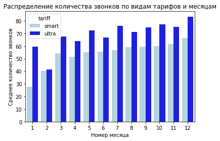

```python
import seaborn as sns

ax = sns.barplot(x='month',
            y='calls_mean',
            hue="tariff",
            data=stats_df,
            palette=['lightblue', 'blue'])

ax.set_title('Распределение количества звонков по видам тарифов и месяцам')
ax.set(xlabel='Номер месяца', ylabel='Среднее количество звонков');
```

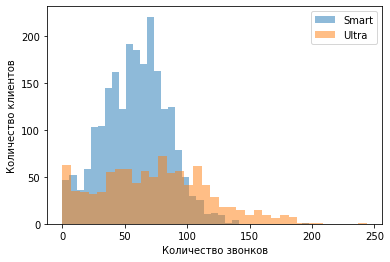

```python
import matplotlib.pyplot as plt

user_behavior.groupby('tariff')['calls'].plot(kind='hist', bins=35, alpha=0.5)
plt.legend(['Smart', 'Ultra'])
plt.xlabel('Количество звонков')
plt.ylabel('Количество клиентов')
plt.show()
```

Распределение средней продолжительности звонков по видам тарифов и месяцам

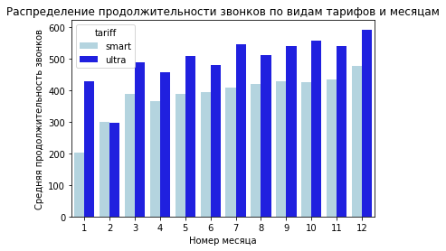

```python
ax = sns.barplot(x='month',
            y='minutes_mean',
            hue="tariff",
            data=stats_df,
            palette=['lightblue', 'blue'])

ax.set_title('Распределение продолжительности звонков по видам тарифов и месяцам')
ax.set(xlabel='Номер месяца', ylabel='Средняя продолжительность звонков');
```

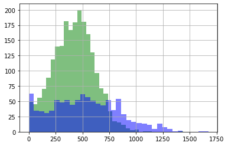

```python
user_behavior[user_behavior['tariff'] =='smart']['minutes'].hist(bins=35, alpha=0.5, color='green')
user_behavior[user_behavior['tariff'] =='ultra']['minutes'].hist(bins=35, alpha=0.5, color='blue');
```

Распределение среднего количества сообщений по видам тарифов и месяцам

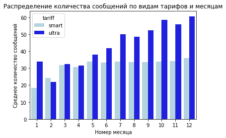

```python
ax = sns.barplot(x='month',
            y='messages_mean',
            hue="tariff",
            data=stats_df,
            palette=['lightblue', 'blue']
)

ax.set_title('Распределение количества сообщений по видам тарифов и месяцам')
ax.set(xlabel='Номер месяца', ylabel='Среднее количество сообщений');
```

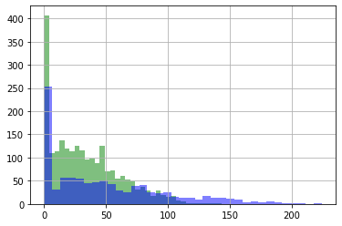

```python
user_behavior[user_behavior['tariff'] =='smart']['messages'].hist(bins=35, alpha=0.5, color='green')
user_behavior[user_behavior['tariff'] =='ultra']['messages'].hist(bins=35, alpha=0.5, color='blue');
```

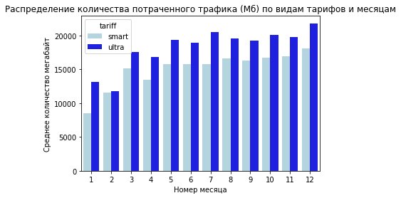

```python
ax = sns.barplot(x='month',
            y='sessions_mean',
            hue="tariff",
            data=stats_df,
            palette=['lightblue', 'blue']
)

ax.set_title('Распределение количества потраченного трафика (Мб) по видам тарифов и месяцам')
ax.set(xlabel='Номер месяца', ylabel='Среднее количество мегабайт');
```

Сравнение потраченных мегабайт среди пользователей тарифов Smart и Ultra

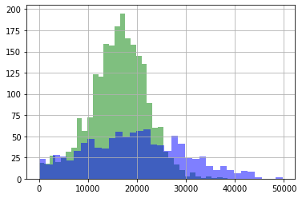

```python
user_behavior[user_behavior['tariff'] =='smart']['mb_used'].hist(bins=35, alpha=0.5, color='green')
user_behavior[user_behavior['tariff'] =='ultra']['mb_used'].hist(bins=35, alpha=0.5, color='blue');
```

Меньше всего пользователи использовали интернет в январе, феврале и апреле. Чаще всего абоненты тарифа Smart тратят 15-17 Гб, а абоненты тарифного плана Ultra - 19-21 ГБ.

### Проверка гипотез

**Задание 28.** Проверка гипотезы: средняя выручка пользователей тарифов «Ультра» и «Смарт» различаются;

```
H_0: Выручка (total_cost) пользователей "Ультра" = выручка (total_cost) пользователей "Смарт"`
H_a: Выручка (total_cost) пользователей "Ультра" ≠ выручка (total_cost) пользователей "Смарт"`
alpha = 0.05
```

```python
from scipy import stats as st
```

```python
#array1 = user_behavior[user_behavior['tariff'] =='ultra'].total_cost.values

#array2 = user_behavior[user_behavior['tariff'] =='smart'].total_cost.values #вызов метода для проверки гипотезы

results = st.ttest_ind(
    user_behavior.loc[user_behavior.tariff =='ultra','total_cost'],
    user_behavior.loc[user_behavior.tariff =='smart','total_cost'],
    equal_var=False)

alpha = .05   #задайте значение уровня значимости

print(results.pvalue)
#print('p-значение:', results.pvalue)

if results.pvalue < alpha:
    print("Отвергаем нулевую гипотезу")
else:
    print("Не получилось отвергнуть нулевую гипотезу")

# вывод значения p-value на экран
# условный оператор с выводом строки с ответом
```

```
4.2606313931076085e-250
Отвергаем нулевую гипотезу
```

**Задание 29.** Проверка гипотезы: пользователи из Москвы приносят больше выручки, чем пользователи из других городов;

[output not shown]

```python
user_behavior.head(2)
```

|  | user_id | month | calls | mb_used | minutes | messages | age | churn_date | city | first_name | ... | rub_per_message | rub_per_minute | paid_minutes | paid_messages | paid_mb | paid_gb | cost_minutes | cost_messages | cost_gb | total_cost |
| --- | --- | --- | --- | --- | --- | --- | --- | --- | --- | --- | --- | --- | --- | --- | --- | --- | --- | --- | --- | --- | --- |
| 0 | 1000 | 5 | 22.0 | 2253.49 | 159.0 | 22.0 | 52 | NaT | Краснодар | Рафаил | ... | 1 | 1 | 0.0 | 0.0 | 0.0 | 0 | 0.0 | 0.0 | 0 | 1950.0 |
| 1 | 1000 | 6 | 43.0 | 23233.77 | 172.0 | 60.0 | 52 | NaT | Краснодар | Рафаил | ... | 1 | 1 | 0.0 | 0.0 | 0.0 | 0 | 0.0 | 0.0 | 0 | 1950.0 |

2 rows × 28 columns

```python
user_behavior[user_behavior['city'] =='Москвы']
```

|  | user_id | month | calls | mb_used | minutes | messages | age | churn_date | city | first_name | ... | rub_per_message | rub_per_minute | paid_minutes | paid_messages | paid_mb | paid_gb | cost_minutes | cost_messages | cost_gb | total_cost |
| --- | --- | --- | --- | --- | --- | --- | --- | --- | --- | --- | --- | --- | --- | --- | --- | --- | --- | --- | --- | --- | --- |

0 rows × 28 columns

```python
array1 = user_behavior[user_behavior['city'] =='Москва'].total_cost.values

array2 = user_behavior[user_behavior['city'] != 'Москва'].total_cost.values #вызов метода для проверки гипотезы

results = st.ttest_ind (array1, array2)

alpha = .05   #задайте значение уровня значимости


print('p-значение:', results.pvalue/2)

if results.pvalue/2 < alpha and array1.mean() < array2.mean():
    print("Отвергаем нулевую гипотезу")
else:
    print("Не получилось отвергнуть нулевую гипотезу")


# results = вызов метода для проверки гипотезы

# alpha = задайте значение уровня значимости

# вывод значения p-value на экран
# условный оператор с выводом строки с ответом
```

```
p-значение: 0.2720076455835112
Не получилось отвергнуть нулевую гипотезу
```